# Regression Analysis Course Project

Vicki Cocco

June 24, 2017

## Motor Trend 1970’s Automobile Transmission Impact on MPG

### Executive Summary

#### Based on the given data and input from a Systems Design Engineer from the

#### automobile industry, this report will:

#### Determine if a manual or automatic transmission was better for miles per gallon fuel usage.

#### Quantify the MPG difference between manual and automatic transmissions.

#### The intended audience for this report are people interested in the interaction of

#### transmission type and MPG and who have a working knowledge of common statistics but

#### not linear regression techniques.

> Basis of analysis: In order to just focus on the transmission type impact on MPG, the industry expert recommended focusing and the data specific to transmission information such as the number of forward gears and the rear axel gear ratio. He also advised that the drivers should be assumed of the same ability, inexperienced drivers will affect the MPG of manual transmissions. That information was extracted from the given data and a portion of it is listed in Table 1.

> Image 2 shows the number of gears for each transmission type over the cars tested. Manual transmissions have data for 4 and 5 gears and automatic transmissions have data for 3 and 4 gears. It cannot be concluded that transmission type alone accounts for the increase in MPG for manual transmissions, the 3rd and 5th gears might also affect the MPG. The success of the relationship between transmission type alone and MPG may be influenced by the number of gears. Image 3 shows the the MPG for both types of transmissions accross the common 4th gear. Although there is still an MPG advantage of 5.225 for manual transmissions the data analysis p-value of 0.108 does not have strong support for the absolute conclusion that Manual transmissions have an MPG advantage across common gears.

### Appendix

#### Table 1

| Miles Per Gallon | Number of Forward Gears | Rear Axel Ratio | Transmission Type |
| --- | --- | --- | --- |
| 21.0 | 4 | 3.90 | Manual |
| 21.0 | 4 | 3.90 | Manual |
| 22.8 | 4 | 3.85 | Manual |
| 21.4 | 3 | 3.08 | Automatic |
| 18.7 | 3 | 3.15 | Automatic |
| 18.1 | 3 | 2.76 | Automatic |

#### Table 2

|  | Number of Forward Gears | Average MPG |
| --- | --- | --- |
| dt3 | 3 | 16.11 |
| dt4 | 4 | 24.53 |
| dt5 | 5 | 21.38 |

#### Table 3

```
##
## Call:
## lm(formula = mpg ~ Transmission, data = dtCars)
##
## Residuals:
##     Min      1Q  Median      3Q     Max
## -9.3923 -3.0923 -0.2974  3.2439  9.5077
##
## Coefficients:
##                    Estimate Std. Error t value Pr(>|t|)
## (Intercept)          17.147      1.125  15.247 1.13e-15 ***
## TransmissionManual    7.245      1.764   4.106 0.000285 ***
## ---
## Signif. codes:  0 '***' 0.001 '**' 0.01 '*' 0.05 '.' 0.1 ' ' 1
##
## Residual standard error: 4.902 on 30 degrees of freedom
## Multiple R-squared:  0.3598, Adjusted R-squared:  0.3385
## F-statistic: 16.86 on 1 and 30 DF,  p-value: 0.000285
```

#### Table 4

```
##
## Call:
## lm(formula = mpg ~ Transmission, data = dtCars, subset = (gears ==
##     "4"))
##
## Residuals:
##     Min      1Q  Median      3Q     Max
## -5.2750 -3.8250 -0.4125  3.5437  7.6250
##
## Coefficients:
##                    Estimate Std. Error t value Pr(>|t|)
## (Intercept)          21.050      2.416   8.713 5.53e-06 ***
## TransmissionManual    5.225      2.959   1.766    0.108
## ---
## Signif. codes:  0 '***' 0.001 '**' 0.01 '*' 0.05 '.' 0.1 ' ' 1
##
## Residual standard error: 4.832 on 10 degrees of freedom
## Multiple R-squared:  0.2377, Adjusted R-squared:  0.1615
## F-statistic: 3.118 on 1 and 10 DF,  p-value: 0.1079
```

#### Table 5

```
##
## Call:
## lm(formula = mpg ~ Transmission + drat, data = dtCars)
##
## Residuals:
##     Min      1Q  Median      3Q     Max
## -9.5802 -2.5206 -0.5153  2.4419  8.5198
##
## Coefficients:
##                    Estimate Std. Error t value Pr(>|t|)
## (Intercept)          -1.950      7.073  -0.276   0.7848
## TransmissionManual    2.807      2.282   1.230   0.2286
## drat                  5.811      2.130   2.728   0.0107 *
## ---
## Signif. codes:  0 '***' 0.001 '**' 0.01 '*' 0.05 '.' 0.1 ' ' 1
##
## Residual standard error: 4.448 on 29 degrees of freedom
## Multiple R-squared:  0.4906, Adjusted R-squared:  0.4554
## F-statistic: 13.96 on 2 and 29 DF,  p-value: 5.659e-05
```

#### Table 6

```
##
## Call:
## lm(formula = mpg ~ drat, data = dtCars)
##
## Residuals:
##     Min      1Q  Median      3Q     Max
## -9.0775 -2.6803 -0.2095  2.2976  9.0225
##
## Coefficients:
##             Estimate Std. Error t value Pr(>|t|)
## (Intercept)   -7.525      5.477  -1.374     0.18
## drat           7.678      1.507   5.096 1.78e-05 ***
## ---
## Signif. codes:  0 '***' 0.001 '**' 0.01 '*' 0.05 '.' 0.1 ' ' 1
##
## Residual standard error: 4.485 on 30 degrees of freedom
## Multiple R-squared:  0.464,  Adjusted R-squared:  0.4461
## F-statistic: 25.97 on 1 and 30 DF,  p-value: 1.776e-05
```

#### Image 1

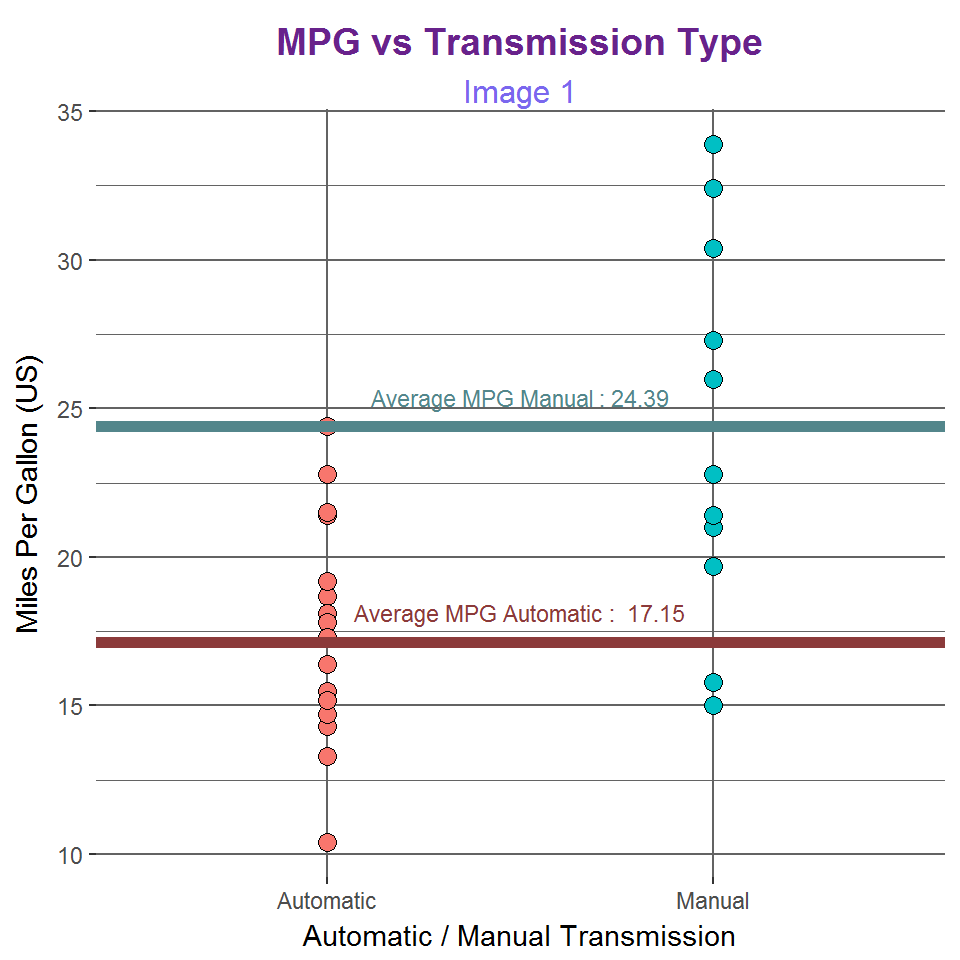

#### Image 2

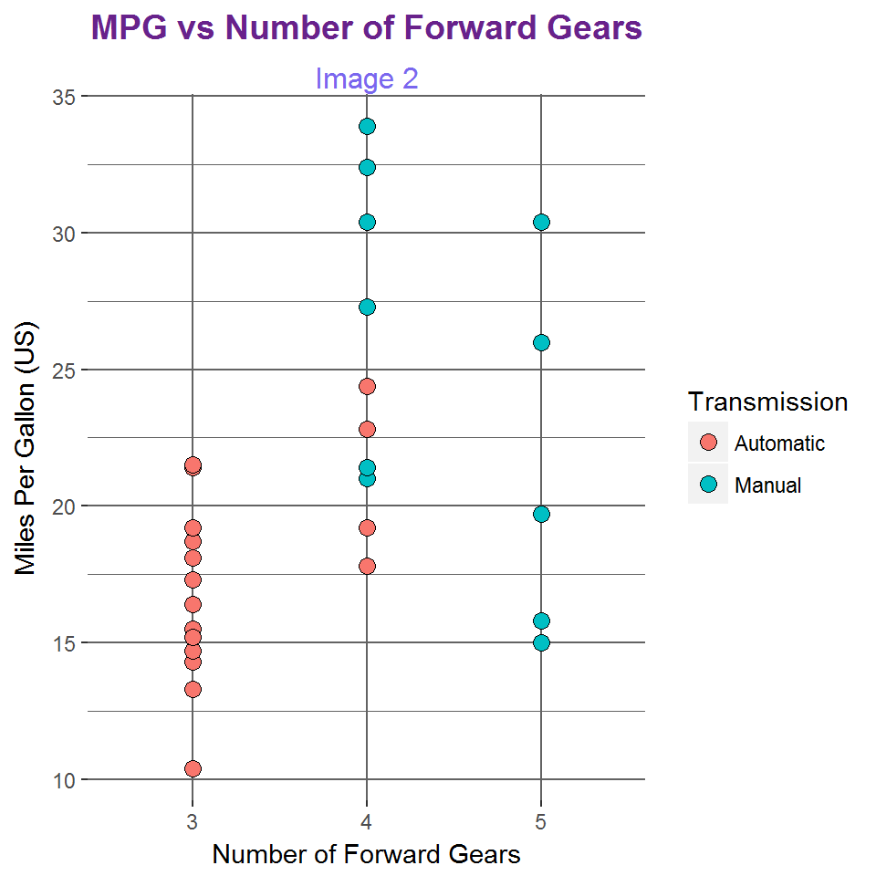

#### Image 3

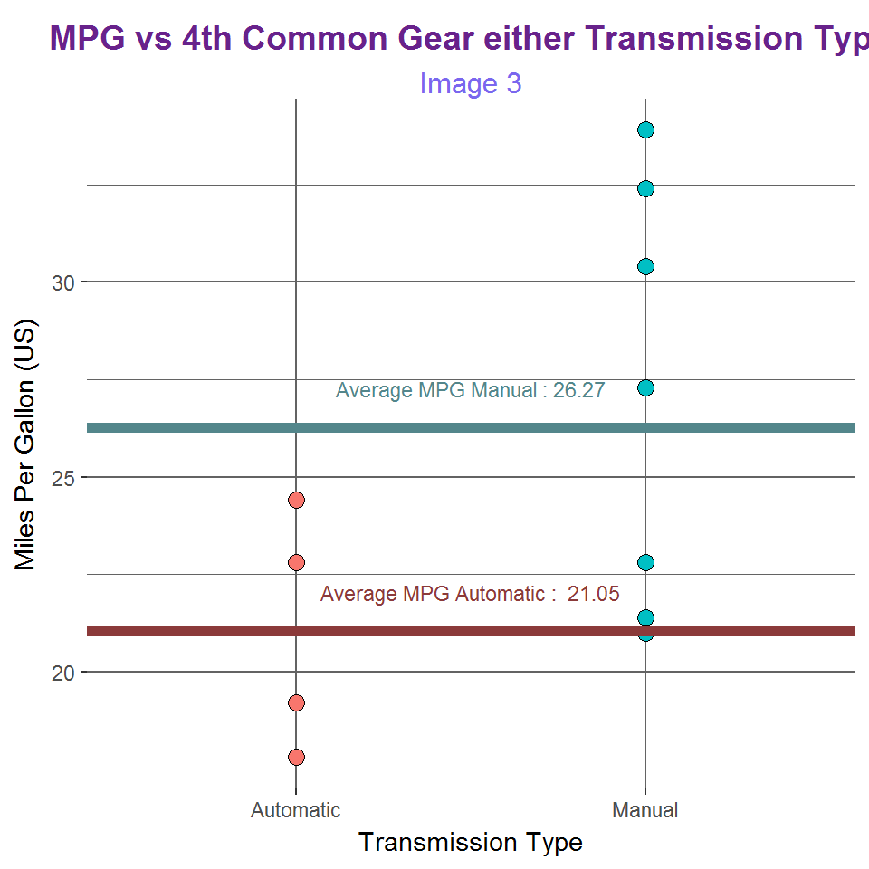

#### Image 5

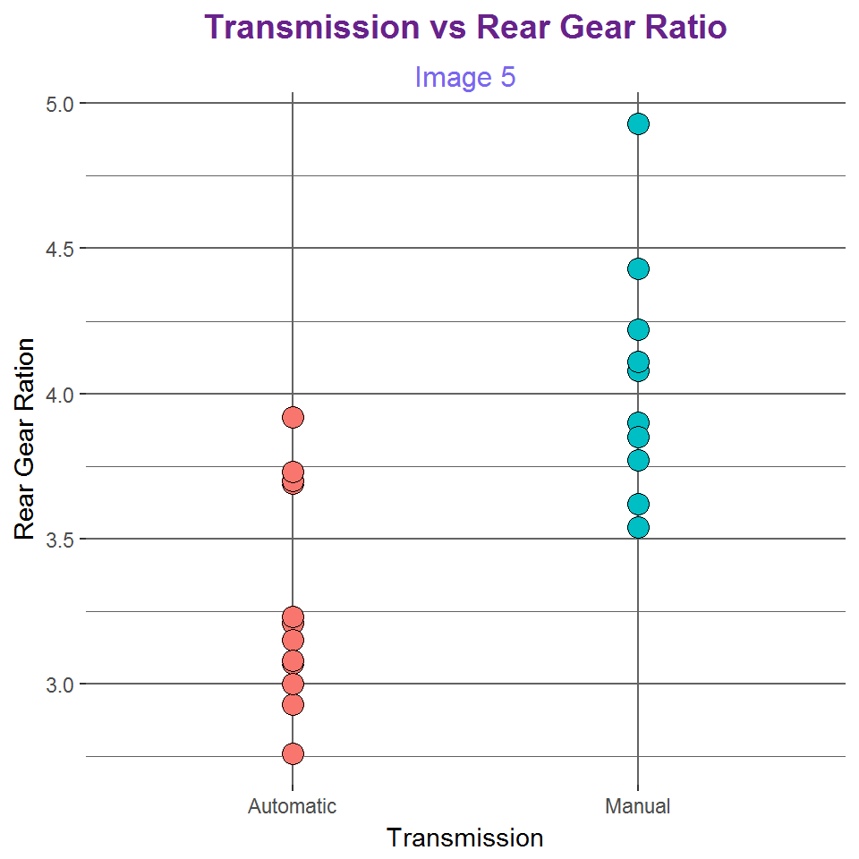

#### Image 6

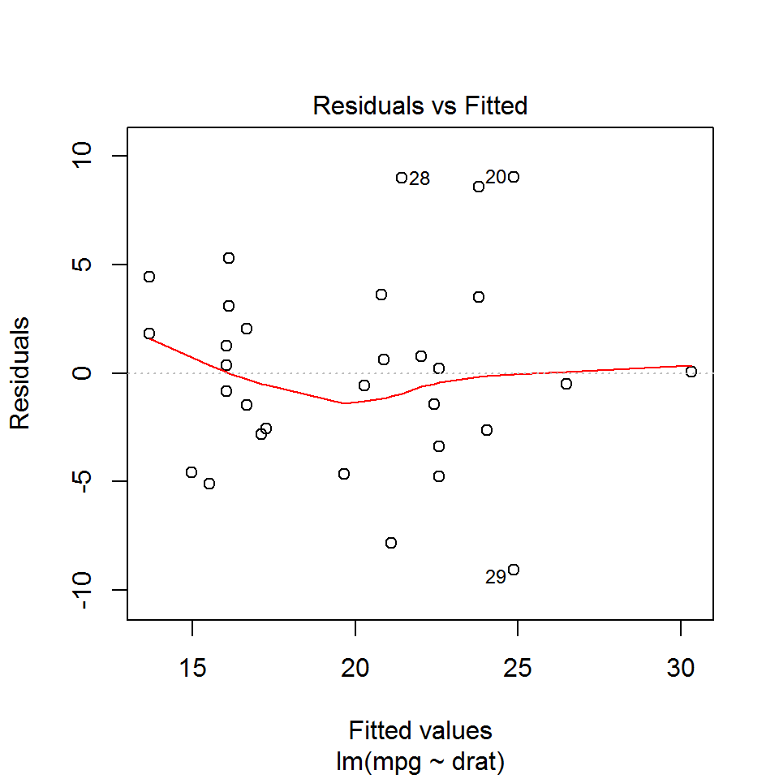

#### Image 7

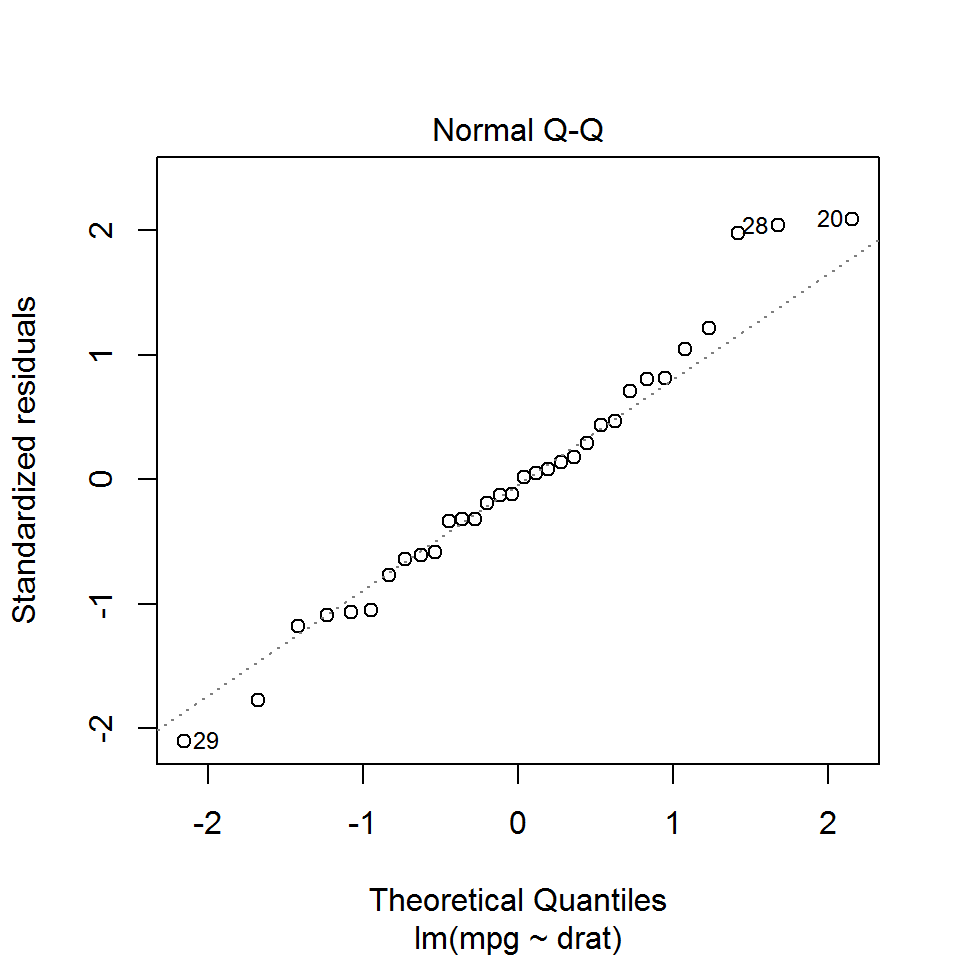